# Compras Estatales

Daniel Czarnievicz, Damian Dapueto, Emanuelle Marsella

Última actualización: viernes 21 junio, 2019, 04:27 p.m.

# 1 Análisis oferentes

La base cuenta con información sobre 8.187 proveedores, los cuales han partidicado de un total de 102.162 compras. El proveedor más frecuente durante 2018 fue Nalfer SA, quien participó en el 4,10% de las compras.

Principales oferentes del Estado en 2018 y 2019

| Proveedor | ID | Cantidad | Proporción |
| --- | --- | --- | --- |
| NALFER S.A. | 216549380018 | 8.931 | 4.10% |
| SANQUILCO SOCIEDAD ANONIMA | 217009690015 | 4.357 | 2.00% |
| MERCOLUZ S A | 211454500015 | 2.562 | 1.18% |
| TERCIR S R L | 210908930011 | 2.049 | 0.94% |
| MENASOL SOCIEDAD ANONIMA | 216577410015 | 1.799 | 0.83% |
| BANCO DE PREVISION SOCIAL | 213054160019 | 1.707 | 0.78% |
| RIBOIRA PINTOS MARIANA | 216359040011 | 1.542 | 0.71% |
| SCALABRINI DE MAINE JORGE DANIEL | 212319150018 | 1.483 | 0.68% |
| VARELA HNOS. SOCIEDAD ANONIMA | 210090180011 | 1.470 | 0.68% |
| ISAFER LTDA | 212363870012 | 1.422 | 0.65% |

# 2 Análisis compras

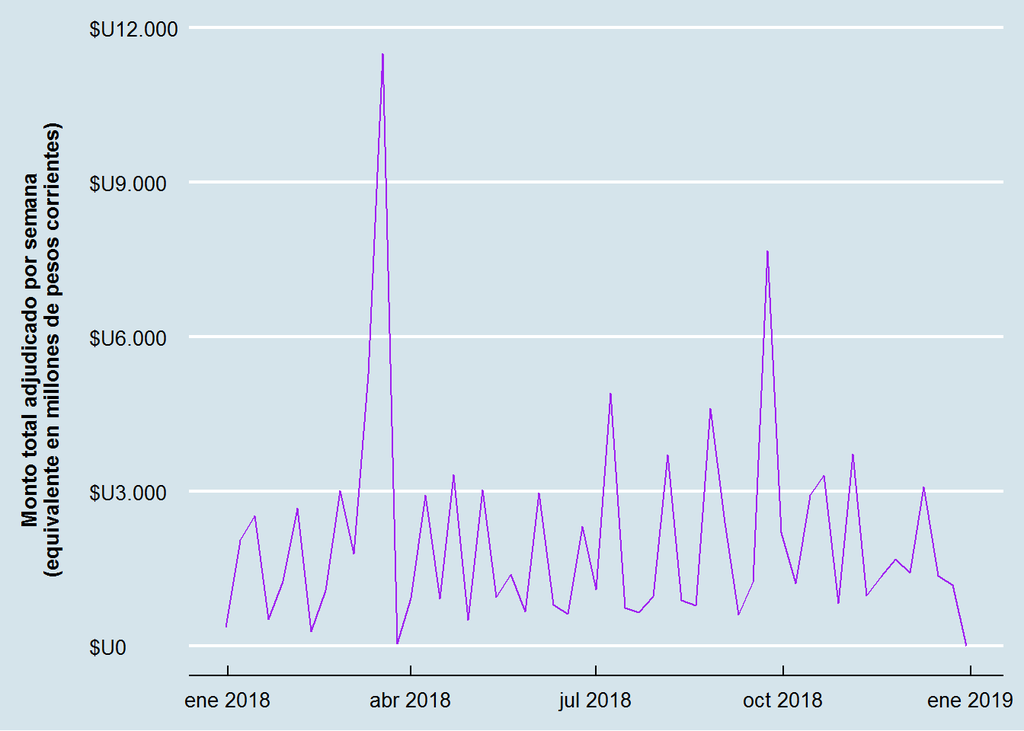

Evolución del monto total adjudicado por mes (en millones de pesos corrientes)

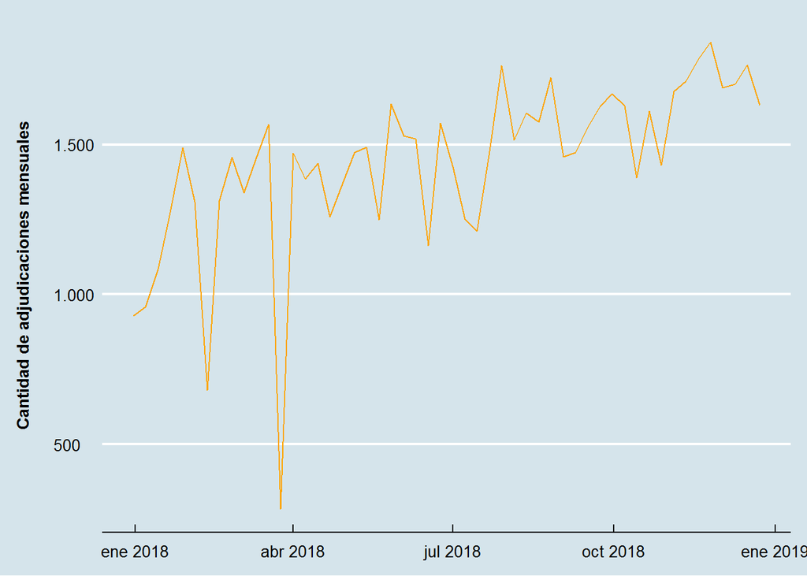

Evolución de la cantidad de adjudicaciones mensuales

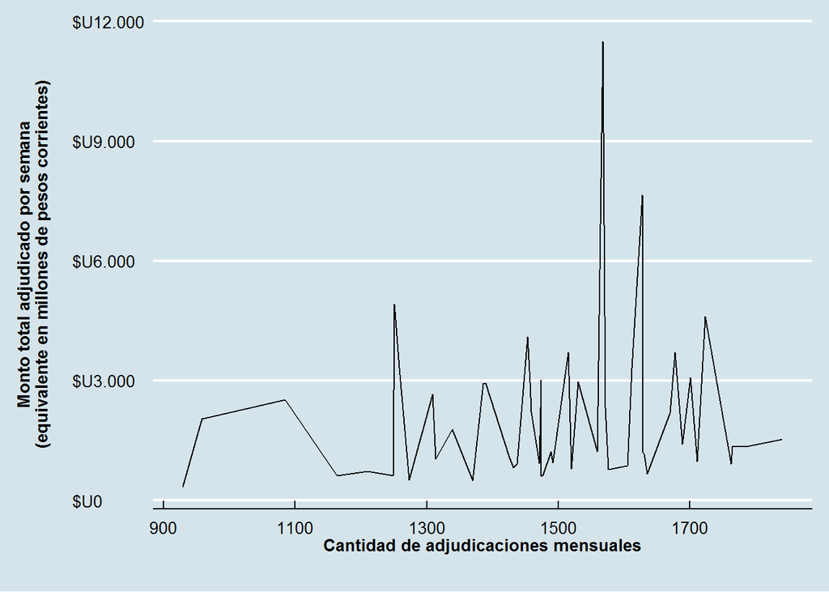

Monto total adjudicado por semana en función de la cantidad de adjudicaciones realizadas.

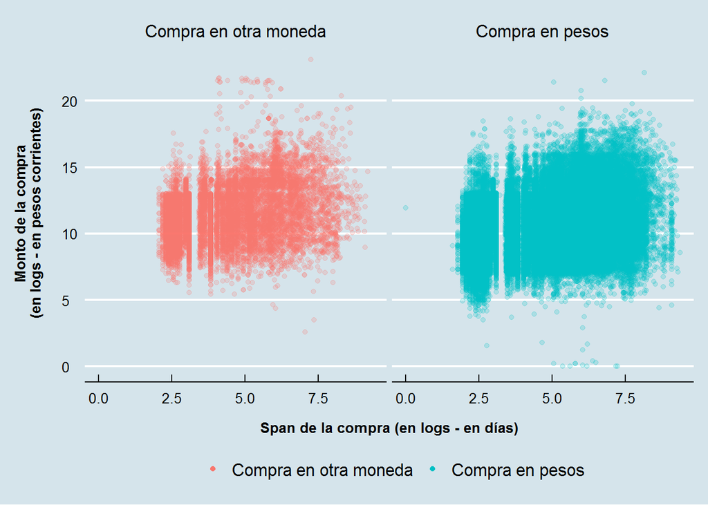

Asociación entre el tiempo que requiró concluir la compra (span) y el monto involucrado en la compra según moneda de la compra. No parecería existir una relación entre las mismas.

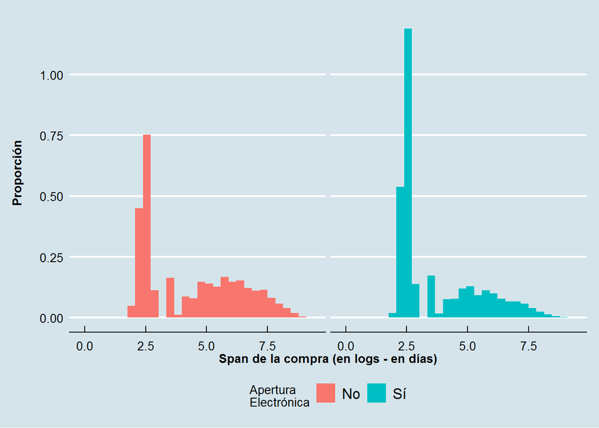

Distribución del logaritmo del tiempo que requiró concluir la compra (span) según si la misma tuvo o no apertura electrónica.

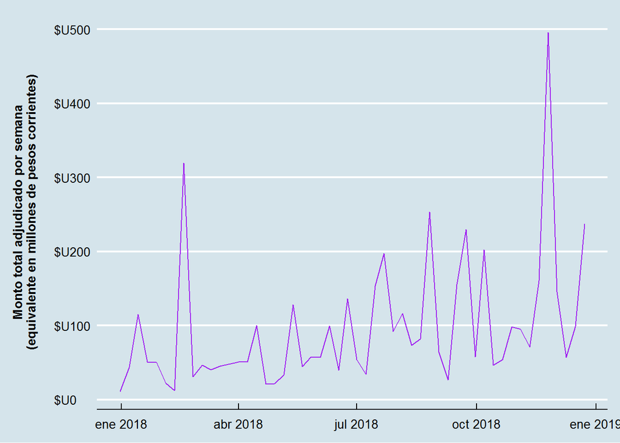

Evolución del monto total adjudicado por mes por la intendencia de Montevideo (en millones de pesos corrientes)

Se puede observar que el monto total adjudicado semanalmente por la Intendencia de Montevideo se mantiene generalmente en una franja de entre 0 y 300 millones de pesos uruguayos.

Existe únicamente un pico, sobre el final del año 2018, cuando se adjudicaron unos 500 millones de pesos.

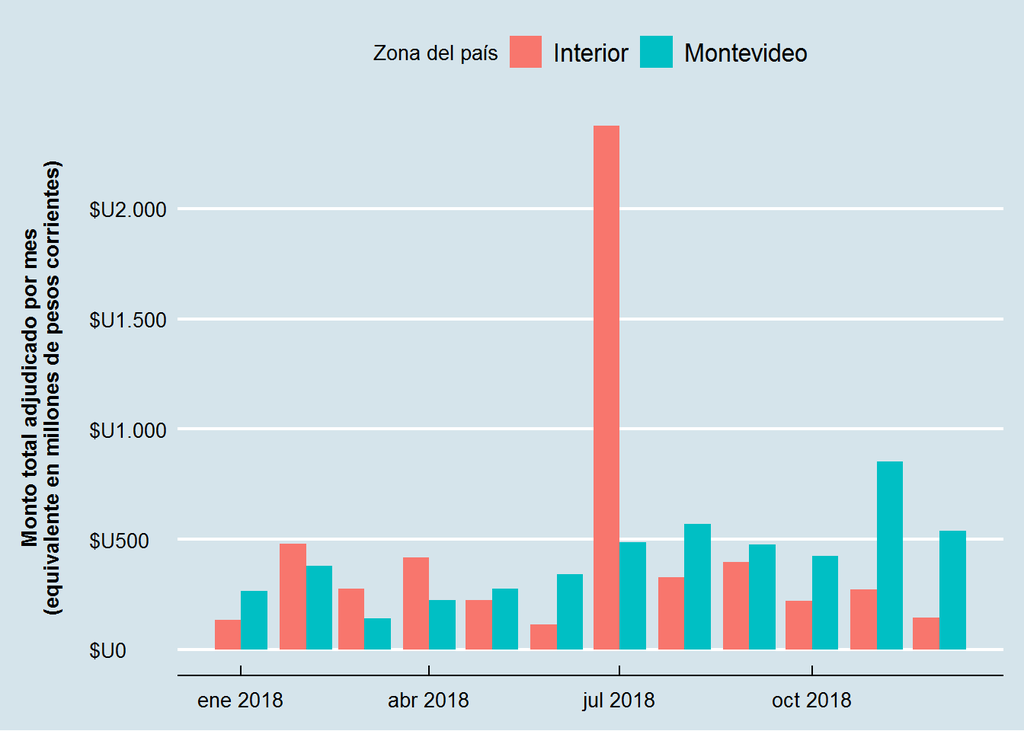

Evolución del monto total adjudicado por mes por las intendencias del país (en millones de pesos corrientes)

Se observa que durante la mayor parte del año, el monto adjudicado por la Intendencia de Montevideo es mayor que el del resto de todas las intendencias de todo el país.

Esto no es cierto en los meses febrero, marzo, y abril, en los cuales el gasto realizado por las intendencias del interior es ligeramente mayor al de la de Montevideo; y en Julio, mes en el que se da el mayor monto de adjudicación de todos, el cual es notablemente superior al resto.

Dicha adjudicación figura en la base como *LICITACIÓN PÚBLICA INTERNACIONAL N° 2.017 8 Llamado para la construcción, operación y mantenimiento de una Planta de Disposición Final de Residuos Sólidos del Departamento de Canelones* y tuvo un monto de $U2.236 millones.